# Ejercicios_Estimacion_lineal

David Caceres

28/2/2022

```r
require(faraway)
```

## Ejercicios del libro de Faraway

### 1. (Ejercicio 1 cap. 2 pág. 30)

The dataset teengamb concerns a study of teenage gambling in Britain. Fit a regression model with the expenditure on gambling as the response and the sex, status, income and verbal score as predictors. Present the output.

```r
data("teengamb")
head(teengamb)
```

```
##   sex status income verbal gamble
## 1   1     51   2.00      8    0.0
## 2   1     28   2.50      8    0.0
## 3   1     37   2.00      6    0.0
## 4   1     28   7.00      4    7.3
## 5   1     65   2.00      8   19.6
## 6   1     61   3.47      6    0.1
```

```r
# Convertimos los datos de la columna "sex" en cualitativos como un factor y hacemos un resumen de los datos

teengamb$sex<-factor(teengamb$sex)
levels(teengamb$sex)<-c("male","female")
summary(teengamb)
```

```
##      sex         status          income           verbal          gamble
##  male  :28   Min.   :18.00   Min.   : 0.600   Min.   : 1.00   Min.   :  0.0
##  female:19   1st Qu.:28.00   1st Qu.: 2.000   1st Qu.: 6.00   1st Qu.:  1.1
##              Median :43.00   Median : 3.250   Median : 7.00   Median :  6.0
##              Mean   :45.23   Mean   : 4.642   Mean   : 6.66   Mean   : 19.3
##              3rd Qu.:61.50   3rd Qu.: 6.210   3rd Qu.: 8.00   3rd Qu.: 19.4
##              Max.   :75.00   Max.   :15.000   Max.   :10.00   Max.   :156.0
```

```r
# Creamos el modelo lineal y lo presentamos
lmod<-lm(gamble ~ sex + status + income + verbal, data=teengamb)
summary(lmod)
```

```
##
## Call:
## lm(formula = gamble ~ sex + status + income + verbal, data = teengamb)
##
## Residuals:
##     Min      1Q  Median      3Q     Max
## -51.082 -11.320  -1.451   9.452  94.252
##
## Coefficients:
##              Estimate Std. Error t value Pr(>|t|)
## (Intercept)  22.55565   17.19680   1.312   0.1968
## sexfemale   -22.11833    8.21111  -2.694   0.0101 *
## status        0.05223    0.28111   0.186   0.8535
## income        4.96198    1.02539   4.839 1.79e-05 ***
## verbal       -2.95949    2.17215  -1.362   0.1803
## ---
## Signif. codes:  0 '***' 0.001 '**' 0.01 '*' 0.05 '.' 0.1 ' ' 1
##
## Residual standard error: 22.69 on 42 degrees of freedom
## Multiple R-squared:  0.5267, Adjusted R-squared:  0.4816
## F-statistic: 11.69 on 4 and 42 DF,  p-value: 1.815e-06
```

#### (a) What percentage of variation in the response is explained by these predictors?

```r
# El porcentaje de variación de la respuesta es R²

lmodsum<-summary(lmod)
lmodsum
```

```
##
## Call:
## lm(formula = gamble ~ sex + status + income + verbal, data = teengamb)
##
## Residuals:
##     Min      1Q  Median      3Q     Max
## -51.082 -11.320  -1.451   9.452  94.252
##
## Coefficients:
##              Estimate Std. Error t value Pr(>|t|)
## (Intercept)  22.55565   17.19680   1.312   0.1968
## sexfemale   -22.11833    8.21111  -2.694   0.0101 *
## status        0.05223    0.28111   0.186   0.8535
## income        4.96198    1.02539   4.839 1.79e-05 ***
## verbal       -2.95949    2.17215  -1.362   0.1803
## ---
## Signif. codes:  0 '***' 0.001 '**' 0.01 '*' 0.05 '.' 0.1 ' ' 1
##
## Residual standard error: 22.69 on 42 degrees of freedom
## Multiple R-squared:  0.5267, Adjusted R-squared:  0.4816
## F-statistic: 11.69 on 4 and 42 DF,  p-value: 1.815e-06
```

```r
#R² puede extraerse del resumen de lmod
names(lmodsum)
```

```
##  [1] "call"          "terms"         "residuals"     "coefficients"
##  [5] "aliased"       "sigma"         "df"            "r.squared"
##  [9] "adj.r.squared" "fstatistic"    "cov.unscaled"
```

```r
# Lo piden en porcentaje
lmodsum$r.squared*100
```

```
## [1] 52.67234
```

#### (b) Which observation has the largest (positive) residual? Give the case number.

```r
e<-lmodsum$residuals
max(e)
```

```
## [1] 94.25222
```

```r
# Posición
which.max(e)
```

```
## 24
## 24
```

#### (c) Compute the mean and median of the residuals.

```r
mean(e)
```

```
## [1] 4.084351e-16
```

```r
median(e)
```

```
## [1] -1.451392
```

#### (d) Compute the correlation of the residuals with the fitted values.

```r
cor(lmod$residuals,lmod$fitted.values)
```

```
## [1] -1.141381e-16
```

#### (e) Compute the correlation of the residuals with the income.

```r
cor(lmod$residuals, teengamb$income)
```

```
## [1] -8.514748e-17
```

#### (f) For all other predictors held constant, what would be the difference in predicted expenditure

on gambling for a male compared to a female?

```r
# Nos piden el coeficiente de regresión para la varaible sex
lmod$coefficients["sexfemale"]
```

```
## sexfemale
## -22.11833
```

### Ejercicio 2

The dataset uswages is drawn as a sample from the Current Population Survey in 1988. Fit a model with weekly wages as the response and years of education and experience as predictors. Report and give a simple interpretation to the regression coefﬁcient for years of education. Now ﬁt the same model but with logged weekly wages. Give an interpretation to the regression coefﬁcient for years of education. Which interpretation is more natural?

```r
data(uswages, package = "faraway")
head(uswages)
```

```
##         wage educ exper race smsa ne mw so we pt
## 6085  771.60   18    18    0    1  1  0  0  0  0
## 23701 617.28   15    20    0    1  0  0  0  1  0
## 16208 957.83   16     9    0    1  0  0  1  0  0
## 2720  617.28   12    24    0    1  1  0  0  0  0
## 9723  902.18   14    12    0    1  0  1  0  0  0
## 22239 299.15   12    33    0    1  0  0  0  1  0
```

```r
# Creamos el modelo lineal
lmod2<-lm(wage ~ educ + exper, data = uswages)
summary(lmod2)
```

```
##
## Call:
## lm(formula = wage ~ educ + exper, data = uswages)
##
## Residuals:
##     Min      1Q  Median      3Q     Max
## -1018.2  -237.9   -50.9   149.9  7228.6
##
## Coefficients:
##              Estimate Std. Error t value Pr(>|t|)
## (Intercept) -242.7994    50.6816  -4.791 1.78e-06 ***
## educ          51.1753     3.3419  15.313  < 2e-16 ***
## exper          9.7748     0.7506  13.023  < 2e-16 ***
## ---
## Signif. codes:  0 '***' 0.001 '**' 0.01 '*' 0.05 '.' 0.1 ' ' 1
##
## Residual standard error: 427.9 on 1997 degrees of freedom
## Multiple R-squared:  0.1351, Adjusted R-squared:  0.1343
## F-statistic:   156 on 2 and 1997 DF,  p-value: < 2.2e-16
```

```r
lmod2$coefficients
```

```
## (Intercept)        educ       exper
## -242.799412   51.175268    9.774767
```

El modelo obtenido se podría expresar de la siguiente forma:

wague = -242.799412 + 51.175268 * educ + 9.774767 * exper

El salario se expresa por semanas, pero la educación y la experiencia se expresan por años. Este modelo nos muestra que el salario se incrementará en 51,17 dólares por año de educación y en 9.77 dólares por año de experiencia.

```r
# Construimos el mismo modelo con los ingresos en forma logaritmoca

waguelog<-lm(log2(wage) ~ educ + exper, data=uswages)
summary(waguelog)
```

```
##
## Call:
## lm(formula = log2(wage) ~ educ + exper, data = uswages)
##
## Residuals:
##     Min      1Q  Median      3Q     Max
## -3.9721 -0.5043  0.1541  0.6320  5.1502
##
## Coefficients:
##             Estimate Std. Error t value Pr(>|t|)
## (Intercept) 6.708992   0.113041   59.35   <2e-16 ***
## educ        0.130573   0.007454   17.52   <2e-16 ***
## exper       0.026082   0.001674   15.58   <2e-16 ***
## ---
## Signif. codes:  0 '***' 0.001 '**' 0.01 '*' 0.05 '.' 0.1 ' ' 1
##
## Residual standard error: 0.9543 on 1997 degrees of freedom
## Multiple R-squared:  0.1749, Adjusted R-squared:  0.174
## F-statistic: 211.6 on 2 and 1997 DF,  p-value: < 2.2e-16
```

```r
waguelog$coefficients
```

```
## (Intercept)        educ       exper
##  6.70899224  0.13057296  0.02608184
```

Obtenemos un segundo modelo que respondería a la siguiente expresión:

log2wague = 6.70899224 + 0.13057296 * educ + 0.02608184 * exper

En este caso, los coeficientes expresan la relación entre el aumento de una unidad en la variable respuesta y el aumento de las explicativas. Por ejemplo:

```r
1/0.13057
```

```
## [1] 7.658727
```

Se necesitarían 7,6 años de educación para doblar el salario (log de base 2).

- La primera expresión parace algo más sencilla de entender y da una referencia algo más clara, aunque los dos modelos son válidos.

### 4. (Ejercicio 4 cap. 2 pág. 30)

The dataset prostate comes from a study on 97 men with prostate cancer who were due to receive a radical prostatectomy. Fit a model with lpsa as the response and lcavol as the predictor. Record the residual standard error and the R 2 . Now add lweight, svi, lbph, age, lcp, pgg45 and gleason to the model one at a time. For each model record the residual standard error and the R 2 . Plot the trends in these two statistics.

```r
data(prostate, package="faraway")
head(prostate)
```

```
##       lcavol lweight age      lbph svi      lcp gleason pgg45     lpsa
## 1 -0.5798185  2.7695  50 -1.386294   0 -1.38629       6     0 -0.43078
## 2 -0.9942523  3.3196  58 -1.386294   0 -1.38629       6     0 -0.16252
## 3 -0.5108256  2.6912  74 -1.386294   0 -1.38629       7    20 -0.16252
## 4 -1.2039728  3.2828  58 -1.386294   0 -1.38629       6     0 -0.16252
## 5  0.7514161  3.4324  62 -1.386294   0 -1.38629       6     0  0.37156
## 6 -1.0498221  3.2288  50 -1.386294   0 -1.38629       6     0  0.76547
```

```r
lmod_p<-lm(lpsa ~ lcavol, data = prostate)
summary(lmod_p)
```

```
##
## Call:
## lm(formula = lpsa ~ lcavol, data = prostate)
##
## Residuals:
##      Min       1Q   Median       3Q      Max
## -1.67625 -0.41648  0.09859  0.50709  1.89673
##
## Coefficients:
##             Estimate Std. Error t value Pr(>|t|)
## (Intercept)  1.50730    0.12194   12.36   <2e-16 ***
## lcavol       0.71932    0.06819   10.55   <2e-16 ***
## ---
## Signif. codes:  0 '***' 0.001 '**' 0.01 '*' 0.05 '.' 0.1 ' ' 1
##
## Residual standard error: 0.7875 on 95 degrees of freedom
## Multiple R-squared:  0.5394, Adjusted R-squared:  0.5346
## F-statistic: 111.3 on 1 and 95 DF,  p-value: < 2.2e-16
```

```r
# El error residual estandar y R²
lmod_psum<-summary(lmod_p)
names(lmod_psum)
```

```
##  [1] "call"          "terms"         "residuals"     "coefficients"
##  [5] "aliased"       "sigma"         "df"            "r.squared"
##  [9] "adj.r.squared" "fstatistic"    "cov.unscaled"
```

```r
lmod_psum$sigma
```

```
## [1] 0.7874994
```

```r
lmod_psum$r.squared
```

```
## [1] 0.5394319
```

```r
# Añadimos weight
lmod_p2<-lm(lpsa ~ lcavol + lweight, data = prostate)
lmod_psum2<-summary(lmod_p2)
lmod_psum2$sigma
```

```
## [1] 0.7506469
```

```r
lmod_psum2$r.squared
```

```
## [1] 0.5859345
```

```r
# Añadimos svi
lmod_p3<-lm(lpsa ~ lcavol + lweight + svi, data = prostate)
lmod_psum3<-summary(lmod_p3)
lmod_psum3$sigma
```

```
## [1] 0.7168094
```

```r
lmod_psum3$r.squared
```

```
## [1] 0.6264403
```

```r
# Añadimos lbph
lmod_p4<-lm(lpsa ~ lcavol + lweight + svi + lbph, data = prostate)
lmod_psum4<-summary(lmod_p4)
lmod_psum4$sigma
```

```
## [1] 0.7108232
```

```r
lmod_psum4$r.squared
```

```
## [1] 0.6366035
```

```r
# Añadimos age

lmod_p5<-lm(lpsa ~ lcavol + lweight + svi + lbph + age, data = prostate)
lmod_psum5<-summary(lmod_p5)
lmod_psum5$sigma
```

```
## [1] 0.7073054
```

```r
lmod_psum5$r.squared
```

```
## [1] 0.6441024
```

```r
# Añadimos lcp

lmod_p6<-lm(lpsa ~ lcavol + lweight + svi + lbph + age + lcp, data = prostate)
lmod_psum6<-summary(lmod_p6)
lmod_psum6$sigma
```

```
## [1] 0.7102135
```

```r
lmod_psum6$r.squared
```

```
## [1] 0.645113
```

```r
# Añadimos pgg45
lmod_p7<-lm(lpsa ~ lcavol + lweight + svi + lbph + age + lcp +
              pgg45, data = prostate)
lmod_psum7<-summary(lmod_p7)
lmod_psum7$sigma
```

```
## [1] 0.7047533
```

```r
lmod_psum7$r.squared
```

```
## [1] 0.6544317
```

```r
# Añadimos gleason
lmod_p8<-lm(lpsa ~ lcavol + lweight + svi + lbph + age + lcp +
              pgg45 + gleason, data = prostate)
lmod_psum8<-summary(lmod_p8)
lmod_psum8$sigma
```

```
## [1] 0.7084155
```

```r
lmod_psum8$r.squared
```

```
## [1] 0.6547541
```

```r
# Creamos un data frame con cada añadido
datos<-data.frame(
"Variables"=c(1,2,3,4,5,6,7,8),
"Error residual"=c(lmod_psum$sigma, lmod_psum2$sigma, lmod_psum3$sigma, lmod_psum4$sigma
,lmod_psum5$sigma, lmod_psum6$sigma, lmod_psum7$sigma, lmod_psum8$sigma),
"R²"=c(lmod_psum$r.squared, lmod_psum2$r.squared, lmod_psum3$r.squared, lmod_psum4$r.squared,
lmod_psum5$r.squared, lmod_psum6$r.squared, lmod_psum7$r.squared, lmod_psum8$r.squared))
datos
```

```
##   Variables Error.residual        R.
## 1         1      0.7874994 0.5394319
## 2         2      0.7506469 0.5859345
## 3         3      0.7168094 0.6264403
## 4         4      0.7108232 0.6366035
## 5         5      0.7073054 0.6441024
## 6         6      0.7102135 0.6451130
## 7         7      0.7047533 0.6544317
## 8         8      0.7084155 0.6547541
```

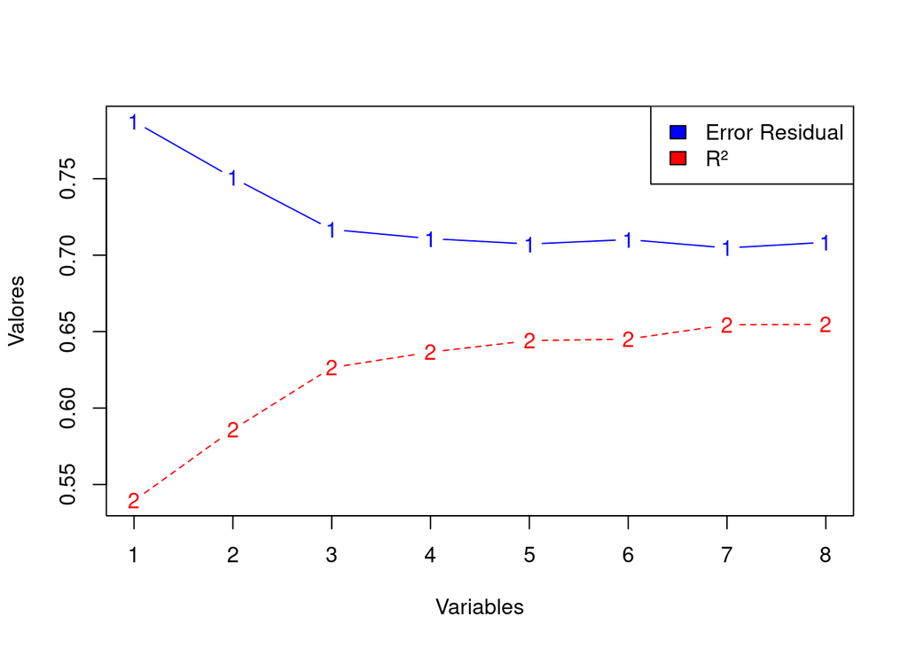

```r
matplot(datos[2:3],type ="b", xlab="Variables", ylab = "Valores",
        col=c("blue","red"))
legend("topright", legend=c("Error Residual", "R²"), fill =c("blue","red"))
```

```r
# Vemos que conforme vamos añadiendo varaibles a la regresión, el error standar
# y r² tienden a confluir poco a poco, es decir el error residual disminuye
# mientras el ajuste es cada vez mejor.
# Esto se debe a que conforme añadimos variables, y estando estas variables
# correlacionadas con la variable respuesta, a mayor número de datos, menor
# varibilidad en los errores y mejor es el ajuste a la recta.
```

### 5. (Ejercicio 5 cap. 2 pág. 30)

Using the prostate data, plot lpsa against lcavol. Fit the regressions of lpsa on lcavol and lcavol on lpsa. Display both regression lines on the plot. At what point do the two lines intersect?

```r
recta1<-lm(lpsa ~ lcavol, data=prostate)
recta2<-lm(lcavol ~ lpsa, data=prostate)
recta1
```

```
##
## Call:
## lm(formula = lpsa ~ lcavol, data = prostate)
##
## Coefficients:
## (Intercept)       lcavol
##      1.5073       0.7193
```

```r
recta2
```

```
##
## Call:
## lm(formula = lcavol ~ lpsa, data = prostate)
##
## Coefficients:
## (Intercept)         lpsa
##     -0.5086       0.7499
```

Para comparar ambas rectas tenemos que invertir una de ellas, ya que si tomamos la ecuación de la recta, y= a + b * x para la recta1, para la recta2 la x y la y deben intercambiarse, de ese modo:

x = a’ + b’ * y y = (x - a’/b) y = -a’/b’ + 1/b’ * x

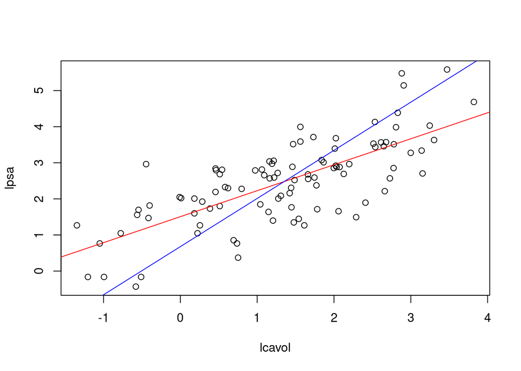

```r
plot(lpsa ~ lcavol, data =prostate)
abline(recta1, col="red")
a_2<-recta2$coefficients[1]
b_2<-recta2$coefficients[2]
a2<- -a_2/b_2
b2<- 1/b_2
abline(a2,b2, col="blue")
```

### 6. (Ejercicio 6 cap. 2 pág. 30)

Thirty samples of cheddar cheese were analyzed for their content of acetic acid, hydrogen sulfide and lactic acid. Each sample was tasted and scored by a panel of judges and the average taste score produced. Use the cheddar data to answer the following:

```r
data(cheddar)
head(cheddar)
```

```
##   taste Acetic   H2S Lactic
## 1  12.3  4.543 3.135   0.86
## 2  20.9  5.159 5.043   1.53
## 3  39.0  5.366 5.438   1.57
## 4  47.9  5.759 7.496   1.81
## 5   5.6  4.663 3.807   0.99
## 6  25.9  5.697 7.601   1.09
```

#### (a) Fit a regression model with taste as the response and the three chemical contents as predictors.

Report the values of the regression coefficients.

```r
cheddarlm<-lm(taste ~ Acetic + H2S + Lactic, data=cheddar)
cheddarlm$coefficients
```

```
## (Intercept)      Acetic         H2S      Lactic
## -28.8767696   0.3277413   3.9118411  19.6705434
```

#### (b) Compute the correlation between the fitted values and the response. Square it. Identify where

this value appears in the regression output.

```r
attach(cheddar)
correlacion<-cor(fitted.values(cheddarlm),taste)
correlacion^2
```

```
## [1] 0.6517747
```

```r
summary(cheddarlm)
```

```
##
## Call:
## lm(formula = taste ~ Acetic + H2S + Lactic, data = cheddar)
##
## Residuals:
##     Min      1Q  Median      3Q     Max
## -17.390  -6.612  -1.009   4.908  25.449
##
## Coefficients:
##             Estimate Std. Error t value Pr(>|t|)
## (Intercept) -28.8768    19.7354  -1.463  0.15540
## Acetic        0.3277     4.4598   0.073  0.94198
## H2S           3.9118     1.2484   3.133  0.00425 **
## Lactic       19.6705     8.6291   2.280  0.03108 *
## ---
## Signif. codes:  0 '***' 0.001 '**' 0.01 '*' 0.05 '.' 0.1 ' ' 1
##
## Residual standard error: 10.13 on 26 degrees of freedom
## Multiple R-squared:  0.6518, Adjusted R-squared:  0.6116
## F-statistic: 16.22 on 3 and 26 DF,  p-value: 3.81e-06
```

```r
# El cuadrado de la correlación coincide con el coeficiente de determinación o R²
```

#### (c) Fit the same regression model but without an intercept term. What is the value of R 2 reported

in the output? Compute a more reasonable measure of the good- ness of fit for this example.

```r
cheddarlm2<-lm(taste ~ 0 + Acetic + H2S + Lactic, data = cheddar)
summary(cheddarlm2)
```

```
##
## Call:
## lm(formula = taste ~ 0 + Acetic + H2S + Lactic, data = cheddar)
##
## Residuals:
##      Min       1Q   Median       3Q      Max
## -15.4521  -6.5262  -0.6388   4.6811  28.4744
##
## Coefficients:
##        Estimate Std. Error t value Pr(>|t|)
## Acetic   -5.454      2.111  -2.583  0.01553 *
## H2S       4.576      1.187   3.854  0.00065 ***
## Lactic   19.127      8.801   2.173  0.03871 *
## ---
## Signif. codes:  0 '***' 0.001 '**' 0.01 '*' 0.05 '.' 0.1 ' ' 1
##
## Residual standard error: 10.34 on 27 degrees of freedom
## Multiple R-squared:  0.8877, Adjusted R-squared:  0.8752
## F-statistic: 71.15 on 3 and 27 DF,  p-value: 6.099e-13
```

```r
# Sacamos el R²
cheddarlm2sum<-summary(cheddarlm2)
names(cheddarlm2sum)
```

```
##  [1] "call"          "terms"         "residuals"     "coefficients"
##  [5] "aliased"       "sigma"         "df"            "r.squared"
##  [9] "adj.r.squared" "fstatistic"    "cov.unscaled"
```

```r
cheddarlm2sum$r.squared
```

```
## [1] 0.8877059
```

```r
# El ajuste en este segundo modelo es mejor que en el primero a priori, pero
# tenemos que tener en cuenta que cuando no se usa el intecepto, las fórmulas
# para clacular R² varían y no son comparables.
```

#### (d) Compute the regression coefficients from the original fit using the QR decomposition showing

your R code.

```r
x<-model.matrix(~ Acetic + H2S + Lactic, data = cheddar)
y<- cheddar$taste
qrx<-qr(x)
dim(qr.Q(qrx))
```

```
## [1] 30  4
```

```r
(f<-t(qr.Q(qrx))%*%y)
```

```
##            [,1]
## [1,] -134.37460
## [2,]   48.10552
## [3,]   46.33591
## [4,]  -23.09366
```

```r
backsolve(qr.R(qrx),f)
```

```
##             [,1]
## [1,] -28.8767696
## [2,]   0.3277413
## [3,]   3.9118411
## [4,]  19.6705434
```

```r
# Los resultados coinciden con el modelo ajustado por mínimos cuadrados
summary(cheddarlm)
```

```
##
## Call:
## lm(formula = taste ~ Acetic + H2S + Lactic, data = cheddar)
##
## Residuals:
##     Min      1Q  Median      3Q     Max
## -17.390  -6.612  -1.009   4.908  25.449
##
## Coefficients:
##             Estimate Std. Error t value Pr(>|t|)
## (Intercept) -28.8768    19.7354  -1.463  0.15540
## Acetic        0.3277     4.4598   0.073  0.94198
## H2S           3.9118     1.2484   3.133  0.00425 **
## Lactic       19.6705     8.6291   2.280  0.03108 *
## ---
## Signif. codes:  0 '***' 0.001 '**' 0.01 '*' 0.05 '.' 0.1 ' ' 1
##
## Residual standard error: 10.13 on 26 degrees of freedom
## Multiple R-squared:  0.6518, Adjusted R-squared:  0.6116
## F-statistic: 16.22 on 3 and 26 DF,  p-value: 3.81e-06
```

### 7. (Ejercicio 7 cap. 2 pág. 31)

An experiment was conducted to determine the effect of four factors on the resistivity of a semi- conductor wafer. The data is found in wafer where each of the four factors is coded as − or + depending on whether the low or the high setting for that factor was used. Fit the linear model resist ~ x1 + x2 + x3 + x4.

```r
data(wafer, package = "faraway")
head(wafer)
```

```
##   x1 x2 x3 x4 resist
## 1  -  -  -  -  193.4
## 2  +  -  -  -  247.6
## 3  -  +  -  -  168.2
## 4  +  +  -  -  205.0
## 5  -  -  +  -  303.4
## 6  +  -  +  -  339.9
```

```r
waferlm<-lm(resist ~ x1 + x2 + x3 + x4, data = wafer)
summary(waferlm)
```

```
##
## Call:
## lm(formula = resist ~ x1 + x2 + x3 + x4, data = wafer)
##
## Residuals:
##     Min      1Q  Median      3Q     Max
## -43.381 -17.119   4.825  16.644  33.769
##
## Coefficients:
##             Estimate Std. Error t value Pr(>|t|)
## (Intercept)   236.78      14.77  16.032 5.65e-09 ***
## x1+            25.76      13.21   1.950 0.077085 .
## x2+           -69.89      13.21  -5.291 0.000256 ***
## x3+            43.59      13.21   3.300 0.007083 **
## x4+           -14.49      13.21  -1.097 0.296193
## ---
## Signif. codes:  0 '***' 0.001 '**' 0.01 '*' 0.05 '.' 0.1 ' ' 1
##
## Residual standard error: 26.42 on 11 degrees of freedom
## Multiple R-squared:  0.7996, Adjusted R-squared:  0.7267
## F-statistic: 10.97 on 4 and 11 DF,  p-value: 0.0007815
```

#### (a) Extract the X matrix using the model.matrix function. Examine this to determine how the

low and high levels have been coded in the model.

```r
mx<-model.matrix(waferlm)
mx
```

```
##    (Intercept) x1+ x2+ x3+ x4+
## 1            1   0   0   0   0
## 2            1   1   0   0   0
## 3            1   0   1   0   0
## 4            1   1   1   0   0
## 5            1   0   0   1   0
## 6            1   1   0   1   0
## 7            1   0   1   1   0
## 8            1   1   1   1   0
## 9            1   0   0   0   1
## 10           1   1   0   0   1
## 11           1   0   1   0   1
## 12           1   1   1   0   1
## 13           1   0   0   1   1
## 14           1   1   0   1   1
## 15           1   0   1   1   1
## 16           1   1   1   1   1
## attr(,"assign")
## [1] 0 1 2 3 4
## attr(,"contrasts")
## attr(,"contrasts")$x1
## [1] "contr.treatment"
##
## attr(,"contrasts")$x2
## [1] "contr.treatment"
##
## attr(,"contrasts")$x3
## [1] "contr.treatment"
##
## attr(,"contrasts")$x4
## [1] "contr.treatment"
```

```r
# Parece que los valores altos corresponden a los 1 o + en el dataset, y
# los más bajos a los 0 o -.
```

#### (b) Compute the correlation in the X matrix. Why are there some missing values in the matrix?

```r
cor(mx)
```

```
##             (Intercept) x1+ x2+ x3+ x4+
## (Intercept)           1  NA  NA  NA  NA
## x1+                  NA   1   0   0   0
## x2+                  NA   0   1   0   0
## x3+                  NA   0   0   1   0
## x4+                  NA   0   0   0   1
```

```r
# Hay valores perdidos porque corresponden a la intersección con el intercepto que tiene 1 como valor
```